# STAD97PROJECT

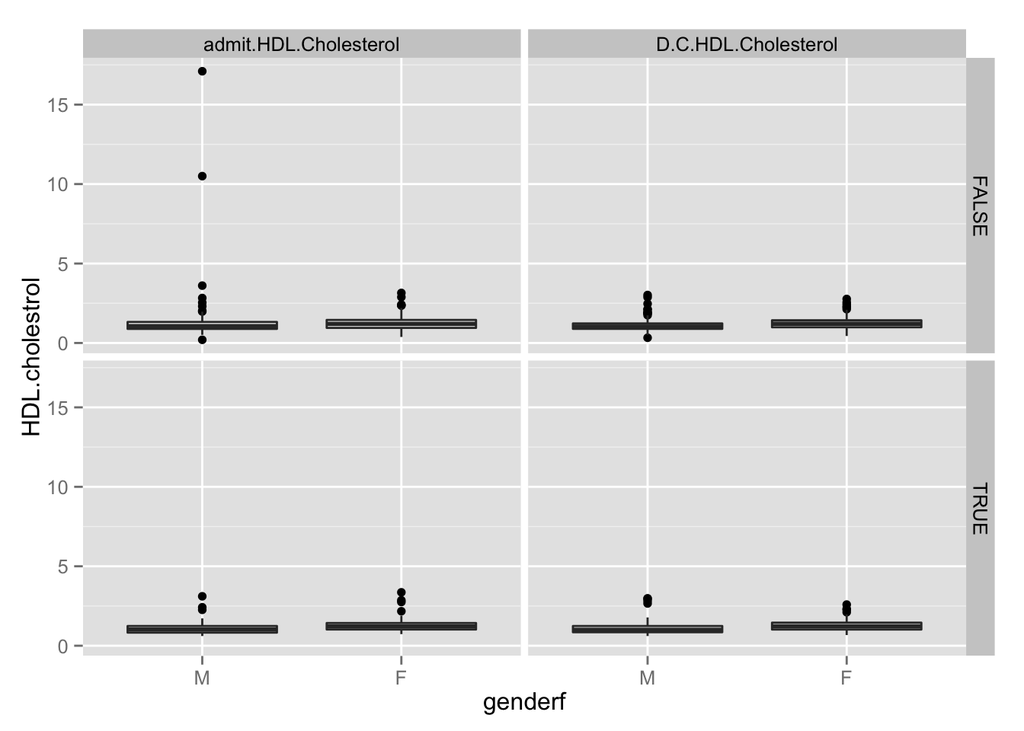

```r
#'with outliers
dataframe %>% gather(admitdischarge,HDL.cholestrol,c(admit.HDL.Cholesterol, D.C.HDL.Cholesterol)) %>%
  ggplot(aes(x=genderf,y=HDL.cholestrol))+geom_boxplot()+facet_grid(Mental.health~admitdischarge)
```

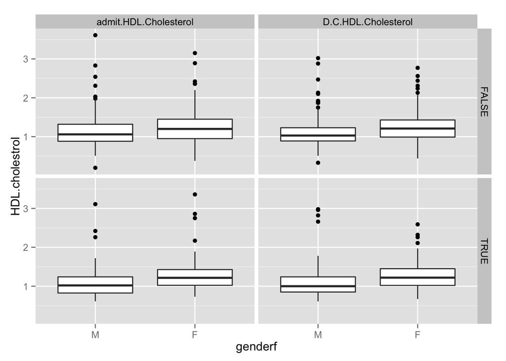

```r
#'without outliers --> make it easier to compare the median
dataframe %>% gather(admitdischarge,HDL.cholestrol,c(admit.HDL.Cholesterol, D.C.HDL.Cholesterol)) %>%
  filter(HDL.cholestrol<5) %>%
  ggplot(aes(x=genderf,y=HDL.cholestrol))+geom_boxplot()+facet_grid(Mental.health~admitdischarge)
```

Changes in HLD.cholesterol level seems to be quite similar for both group of patients, which might suggest that treatment have not much effect on patient’s HDL.cholesterol level

2d. Change in clinical metrics(Lipids level(LDL cholesterol)) for subgroups: mental health patients

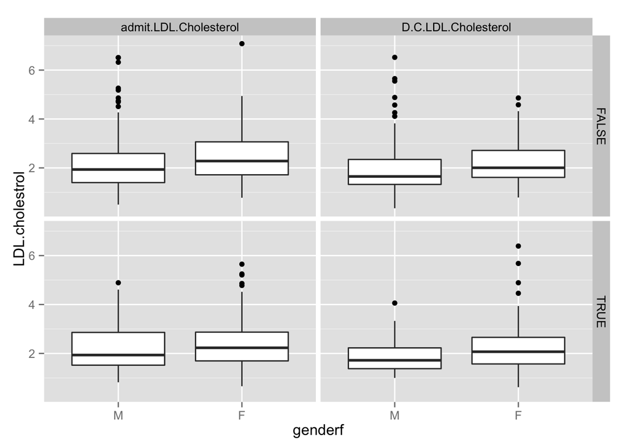

```r
dataframe %>% gather(admitdischarge,LDL.cholestrol,c(admit.LDL.Cholesterol, D.C.LDL.Cholesterol)) %>%
  ggplot(aes(x=genderf,y=LDL.cholestrol))+geom_boxplot()+facet_grid(Mental.health~admitdischarge)
```

2d. Change in clinical metrics(eGFR) for subgroups: mental health patients

```r
dataframe$Mental.health
```

[output not shown]

[output cut: 42 more lines]

```r
aggregate(cbind(admit.eGFR, D.C.eGFR)~Mental.health,data=dataframe,mean)
```

```
##   Mental.health admit.eGFR D.C.eGFR
## 1         FALSE   74.15506 72.32927
## 2          TRUE   87.77273 85.01515
```

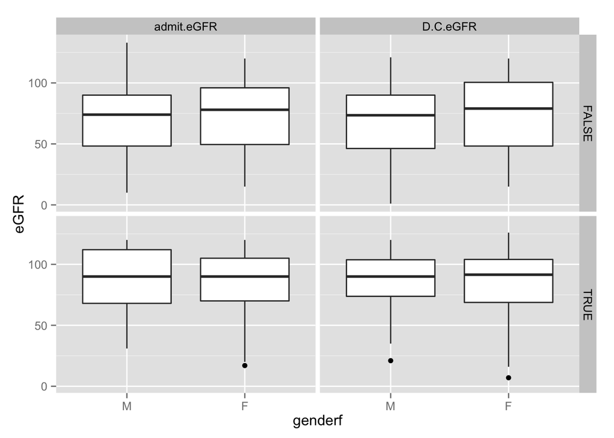

```r
dataframe %>% gather(admitdischarge,eGFR,c(admit.eGFR, D.C.eGFR)) %>%
  ggplot(aes(x=genderf,y=eGFR))+geom_boxplot()+facet_grid(Mental.health~admitdischarge)
```

Mental health might be related to higher eGFR score: both male and female with mental health diagnosis have higher eFGR scores than those who are not diagnosed with mental health.However, the treatment does not seem to improve the score as we see that discharged eGFR remain about the same as admited eGFR for both genders with/without mental health diagnosis.

2d. Change in clinical metrics(micro albumin) for subgroups: mental health patients

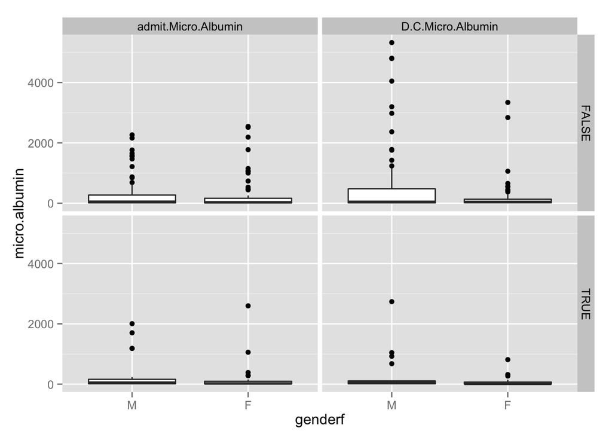

```r
dataframe %>% gather(admitdischarge,micro.albumin,c(admit.Micro.Albumin, D.C.Micro.Albumin)) %>%
  ggplot(aes(x=genderf,y=micro.albumin))+geom_boxplot()+facet_grid(Mental.health~admitdischarge)
```

many outliers shown

numerical summary wwithout difference

```r
dataframe %>% gather(admitdischarge,micro.albumin,c(admit.Micro.Albumin, D.C.Micro.Albumin)) %>% group_by(genderf,agef,admitdischarge,Mental.health) %>% summarise(Q1=quantile(micro.albumin,0.25,na.rm=T),
    med=median(micro.albumin,na.rm=T),Q3=quantile(micro.albumin,0.75,na.rm=T),missing=sum(is.na(micro.albumin)),n=n()) %>% as.data.frame()
```

```
##    genderf    agef      admitdischarge Mental.health     Q1    med      Q3
## 1        M (17,45] admit.Micro.Albumin         FALSE  6.525   9.50  27.500
## 2        M (17,45] admit.Micro.Albumin          TRUE  6.000  17.00  35.700
## 3        M (17,45]   D.C.Micro.Albumin         FALSE  8.000  13.00  37.000
## 4        M (17,45]   D.C.Micro.Albumin          TRUE  8.500  11.00  13.500
## 5        M (45,65] admit.Micro.Albumin         FALSE 16.000  53.00 319.050
## 6        M (45,65] admit.Micro.Albumin          TRUE 18.925  60.50 221.000
## 7        M (45,65]   D.C.Micro.Albumin         FALSE 16.050  58.30 595.750
## 8        M (45,65]   D.C.Micro.Albumin          TRUE 14.750  63.40 538.350
## 9        M (65,80] admit.Micro.Albumin         FALSE 13.750 103.50 274.250
## 10       M (65,80] admit.Micro.Albumin          TRUE 57.000  64.00 112.500
## 11       M (65,80]   D.C.Micro.Albumin         FALSE 11.100  62.00 214.100
## 12       M (65,80]   D.C.Micro.Albumin          TRUE 45.050  83.00  85.000
## 13       M (80,95] admit.Micro.Albumin         FALSE 17.350 119.50 245.850
## 14       M (80,95] admit.Micro.Albumin          TRUE  7.000   7.00   7.000
```

[output cut: 51 more lines]

numerical summary - with difference (discharge-admit)

```r
dataframe %>% mutate(diff=D.C.Micro.Albumin-admit.Micro.Albumin) %>%
  mutate(agef=cut(age,breaks=c(17,44,64,79,95),labels=c("18-44","45-64","65-79","80")))->mutatea

mutatea %>% group_by(genderf,agef,Mental.health) %>% summarise(Q1=quantile(diff,0.25,na.rm=T),
    med=median(diff,na.rm=T),Q3=quantile(diff,0.75,na.rm=T),missing=sum(is.na(diff)),n=n()) %>% as.data.frame()
```

```
##    genderf  agef Mental.health       Q1    med      Q3 missing   n
## 1        M 18-44         FALSE   -1.925  -0.85   0.000      30  36
## 2        M 18-44          TRUE       NA     NA      NA      18  18
## 3        M 45-64         FALSE  -37.400   2.00 327.500     103 122
## 4        M 45-64          TRUE  -58.475 -10.45  39.750      40  50
## 5        M 65-79         FALSE  -23.000  12.00 194.925      66  82
## 6        M 65-79          TRUE  -52.750 -27.50  -2.250      13  15
## 7        M    80         FALSE  -59.725 -21.20  15.000      16  20
## 8        M    80          TRUE       NA     NA      NA       1   1
## 9        F 18-44         FALSE  -91.000 -10.70   0.000      25  30
## 10       F 18-44          TRUE    0.450   2.90   5.350      27  29
## 11       F 45-64         FALSE  -50.500  -7.60  27.700      61  72
## 12       F 45-64          TRUE  -37.650  -9.00  -1.700      38  53
## 13       F 65-79         FALSE   -8.325  -0.60   3.250      44  58
## 14       F 65-79          TRUE   -1.500   0.00  11.000      12  15
## 15       F    80         FALSE -249.000 -81.00 -34.250      13  16
## 16       F    80          TRUE   18.000  18.00  18.000       4   5
```